# **Heróis da Marvel x Heróis da DC**

### por *Luís Felipe Granello de Souza*

> Neste trabalho, analisaremos o panteão de heróis das editoras mais famosas no mundo - *Marvel Comics* e *DC*, reconhecidas pelos sucessos em suas HQs (histórias em quadrinhos). Analisaremos características físicas e categóricas dos heróis, bem como o mais poderoso, o mais popular, a distribuição dentre gêneros e aparições, os poderes típicos por raça e qual lado se sairia melhor num confronto final.

# Seção de Gráficos Univariados

### *1. Fontes de dados*

#### Utilizaremos diversas fontes de dados csv, os arquivos `powers`, `heroes` e `power_strengths`e os arquivos `wiki`, obtidos por buscas na Web.

#### `heroes` contém 734 observações (cada uma, um heroi) e 11 atributos

#### `powers` contém 667 observações (cada uma, um heroi) e 168 atributos

```
## [1] 734  11
```

```
## [1] 667 168
```

```
## Observations: 734
## Variables: 11
## $ nr           <int> 0, 1, 2, 3, 4, 5, 6, 7, 8, 9, 10, 11, 12, 13, 14,...
## $ name         <chr> "A-Bomb", "Abe Sapien", "Abin Sur", "Abomination"...
## $ Gender       <chr> "Male", "Male", "Male", "Male", "Male", "Male", "...
## $ `Eye color`  <chr> "yellow", "blue", "blue", "green", "blue", "blue"...
## $ Race         <chr> "Human", "Icthyo Sapien", "Ungaran", "Human / Rad...
## $ `Hair color` <chr> "No Hair", "No Hair", "No Hair", "No Hair", "Blac...
## $ Height       <dbl> 203, 191, 185, 203, -99, 193, -99, 185, 173, 178,...
## $ Publisher    <chr> "Marvel Comics", "Dark Horse Comics", "DC Comics"...
## $ `Skin color` <chr> "-", "blue", "red", "-", "-", "-", "-", "-", "-",...
## $ Alignment    <chr> "good", "good", "good", "bad", "bad", "bad", "goo...
## $ Weight       <dbl> 441, 65, 90, 441, -99, 122, -99, 88, 61, 81, 104,...
```

```
##        nr            name              Gender           Eye color
##  Min.   :  0.0   Length:734         Length:734         Length:734
##  1st Qu.:183.2   Class :character   Class :character   Class :character
##  Median :366.5   Mode  :character   Mode  :character   Mode  :character
##  Mean   :366.5
##  3rd Qu.:549.8
##  Max.   :733.0
##
##      Race            Hair color            Height       Publisher
##  Length:734         Length:734         Min.   :-99.0   Length:734
##  Class :character   Class :character   1st Qu.:-99.0   Class :character
##  Mode  :character   Mode  :character   Median :175.0   Mode  :character
##                                        Mean   :102.3
##                                        3rd Qu.:185.0
##                                        Max.   :975.0
##
##   Skin color         Alignment             Weight
##  Length:734         Length:734         Min.   :-99.00
##  Class :character   Class :character   1st Qu.:-99.00
##  Mode  :character   Mode  :character   Median : 62.00
##                                        Mean   : 43.86
##                                        3rd Qu.: 90.00
##                                        Max.   :900.00
##                                        NA's   :2
```

### *2. Data Cleansing*

#### Como, em `heroes`, há valores *-99* em *Weight (peso)* e *Height (altura)* , que são fisicamente impossíveis, convertemo-los para *NAs*.

#### E fizemos o mesmo com as células preenchidas por *“-”*.

#### Da mesma forma, é interessante excluirmos colunas desnecessárias e convertemos valores categóricos de algumas colunas em fatores.

#### Em `powers`, convertamos as strings ‘TRUE’ e ‘FALSE’ para valores lógicos

### *3. Exploração de dados*

#### Comecemos por agrupar os dados para vermos as editoras preponderantes:

| Publisher | Qtd_Pers | Percent |
| --- | --- | --- |
| Marvel Comics | 388 | 0.5286104 |
| DC Comics | 215 | 0.2929155 |
| Outras | 94 | 0.1280654 |
| NBC - Heroes | 19 | 0.0258856 |
| Dark Horse Comics | 18 | 0.0245232 |

### *3.1. “*Character-share*” das Editoras*

> Vejamos como é a distribuição criativa de personagens por editora

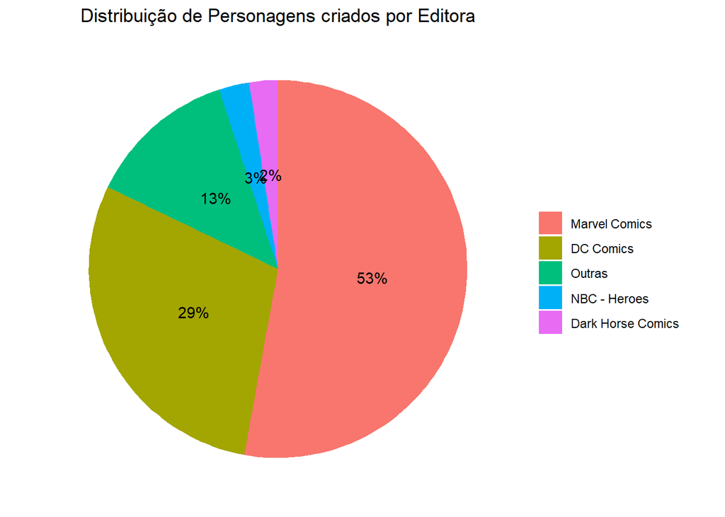

> A partir do nem sempre recomendável gráfico de pizza acima, vemos a distribuição de personagens por editora. *Marvel Comics* e *DC* dominam no polo criativo, tendo direitos autorais sobre 82% dos personagens do *dataset* Comparemos as duas editoras então.

### *3.2. Qual o ranking de herois por poder total?*

> Para saber quais os herois mais poderosos, ponderamos o *binário* (possui / não possui) de cada habilidade específica do heroi pelo valor de escala que pode ser encontrado na [*Database de Super Herois*](https://www.superherodb.com/powers/)

Ranking dos 20 Heróis mais poderosos

| Publisher | name | Poder_Total |
| --- | --- | --- |
| Marvel Comics | One-Above-All | 228.0 |
| Marvel Comics | Living Tribunal | 203.0 |
| DC Comics | Spectre | 188.5 |
| Marvel Comics | Captain Marvel | 176.0 |
| DC Comics | Captain Marvel | 176.0 |
| Marvel Comics | Franklin Richards | 163.0 |
| Marvel Comics | Odin | 147.5 |
| Marvel Comics | Galactus | 147.0 |
| DC Comics | Anti-Monitor | 140.0 |
| DC Comics | Mister Mxyzptlk | 135.5 |
| Marvel Comics | Beyonder | 129.5 |
| DC Comics | Amazo | 123.0 |
| Marvel Comics | Silver Surfer | 113.0 |
| Marvel Comics | Thanos | 113.0 |
| Marvel Comics | Nova | 111.0 |
| Marvel Comics | Nova | 111.0 |
| DC Comics | Dr Manhattan | 106.5 |
| Marvel Comics | Phoenix | 106.0 |
| Marvel Comics | Angel | 105.0 |
| Marvel Comics | Legion | 104.0 |

[figure not shown]

> O desconhecido *“The One-Above-All”* aparenta ser o herói mais poderoso de todos, corroborando com seu nome. *Captain Marvel* tem sua barra representativa bicolorida - tratam-se de dois personagens homônimos dentre os universos. Devido aos direitos autorais, o personagem da *DC* foi reintroduzido como *Shazam!* em 1972.

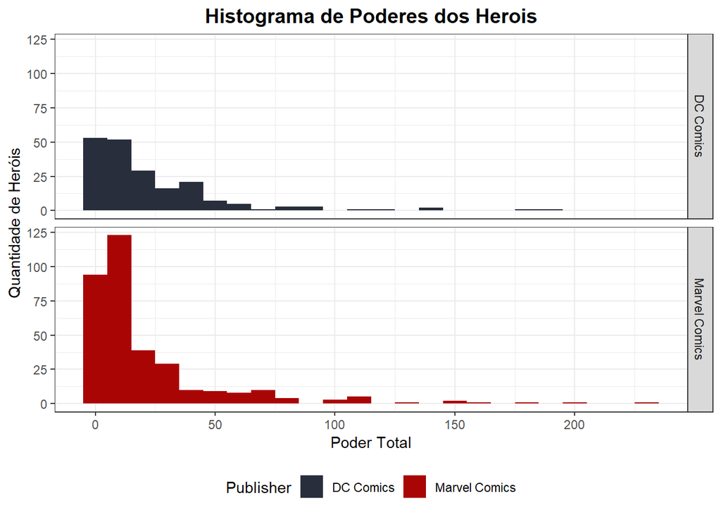

> Pelo distribuição de frequência e níveis de poder, vemos que a *Marvel* leva ampla vantagem, possuindo os herois mais poderosos e, eventualmente, saindo-se melhor em um hipotético conflito de *crossover*

### *3.3. Quais os heróis mais versáteis?*

> Podemos medir a versatilidade de acordo com a diversidade de poderes que um herói tem

[figure not shown]

> Os poderes aracnídeos do *Spidey* (*Homem-Aranha*), aliados ao seu gênio intelectual, fazem dele o herói mais versátil dentre todos.

### *3.4. Popularidade*

> Observemos agora a popularidade de um heroi, podendo ser entendida como número de vezes que ele aparece nas HQs, impulsionando o volume de vendas. Vejamos também a densidade de aparições por ano, para tentarmos ser justos com herois de criação recente e que também são populares

[figure not shown]

[figure not shown]

> A popularidade do *Spidey* é mantida tanto em termos absolutos quanto relativos. Vê-se também que a popularidade de *Wolverine*, *Homem de Ferro* e *Capitão América* também são consistentes.

### *3.5. E quando os autores estavam sem ideias?*

> Quando os autores não tinham ideias de poderes novos, a quais habilidades eles mais recorriam? Em outras palavras: quais poderes são os mais comuns dentre os heróis?

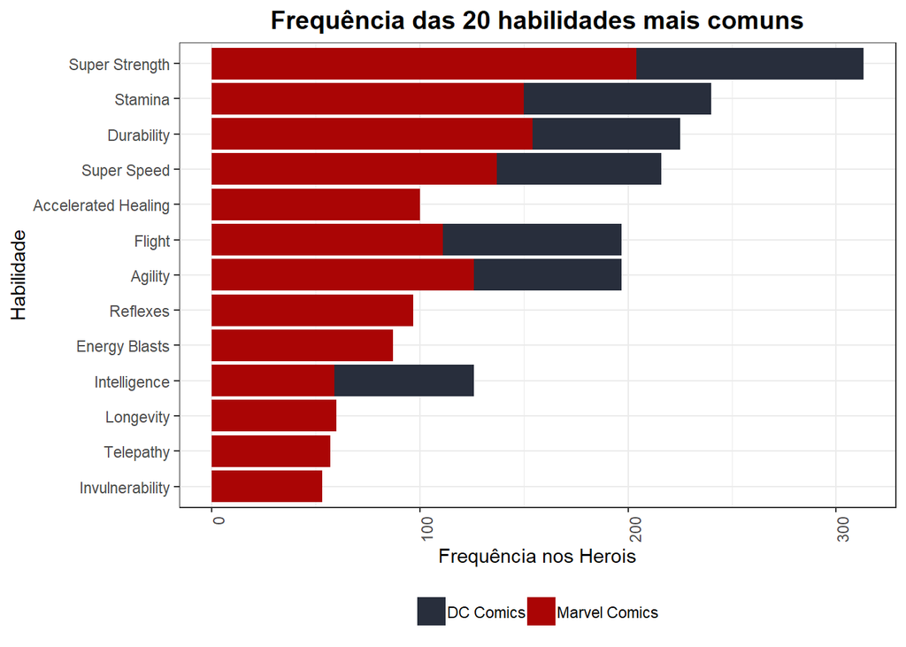

> Intuitivamente, super-força, estamina, durabilidade, super-velocidade, agilidade e voo se provaram como os poderes mais comuns presentes no universo dos quadrinhos. Dado o maior número de heróis na *Marvel*, é de se esperar que o volume das habilidades mais comuns sejam maior nesta editora que na *DC*.

### *3.6. Distribuição de Gênero*

> Uma curiosidade que pode rodear o mundo dos quadrinhos é como se dá a repartição de papéis entre protagonistas masculinos e femininos. Vejamos

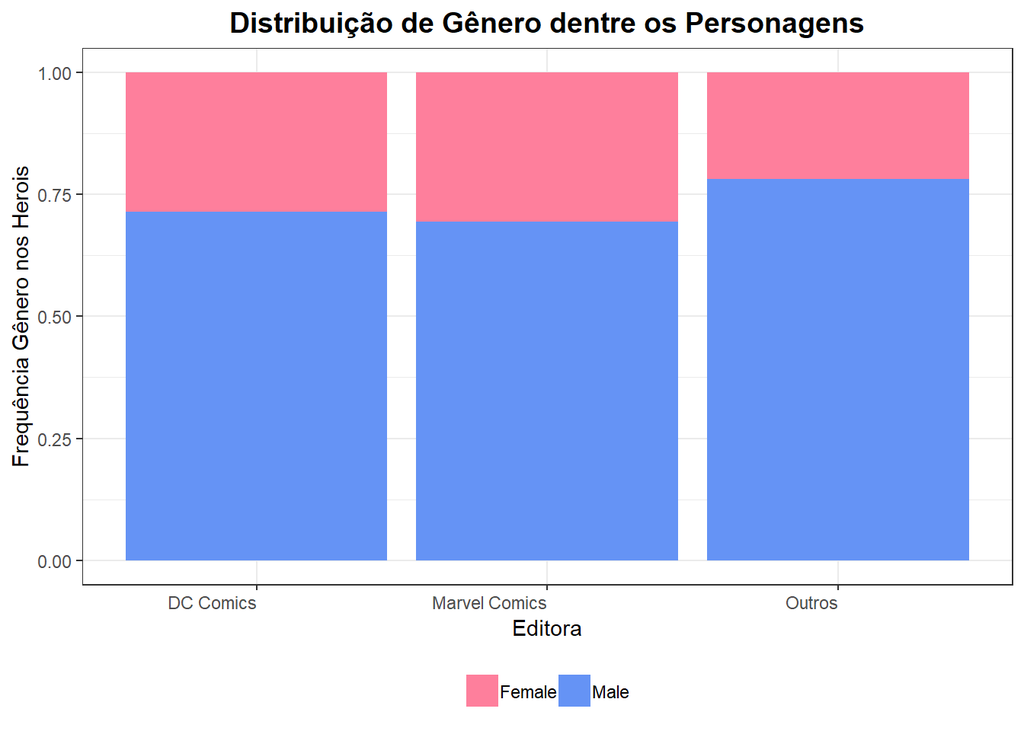

### *3.7. Distribuição de Bem x Mal*

> E como vai o maniqueísmo nos quadrinhos? Será que a quantidade de mocinhos é muito superior a de vilões? Vejamos

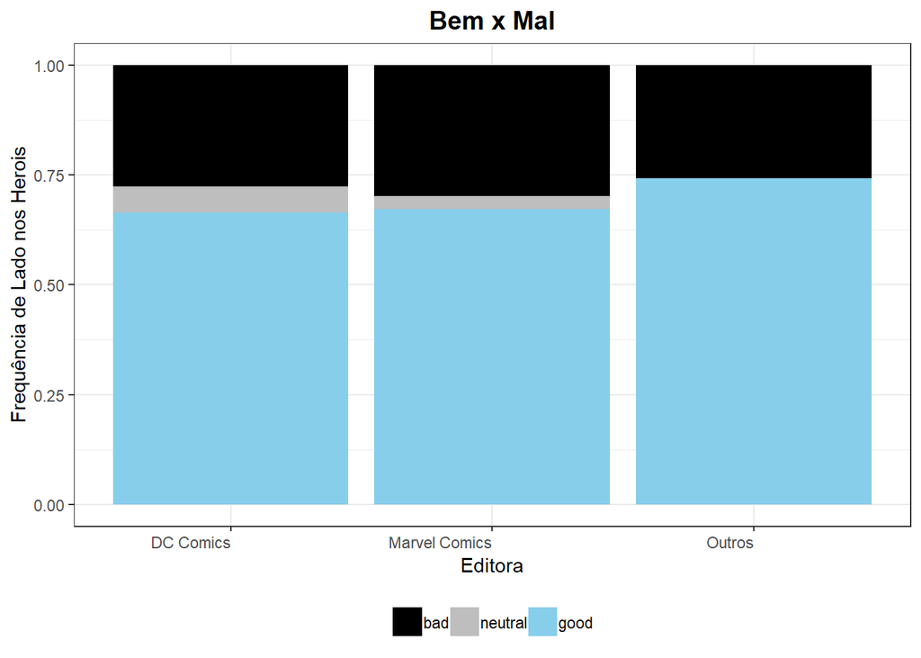

> Pode-se notar que a *DC* possui, comparativamente, a maior parte de personagens neutros. Isto possibilita manobras criativas e *plot twists* interessantes nos roteiros. A *Marvel*, por outro lado, é quem possui mais vilões em relação ao todo.

### *3.8. Distribuição de Raças*

> Quadrinhos, por diversas vezes, apresentam viagens planetárias, espaço-temporais e outras sandices que a ficção permite. Será que a raça humana é uma minoria nestas histórias de fantasias?

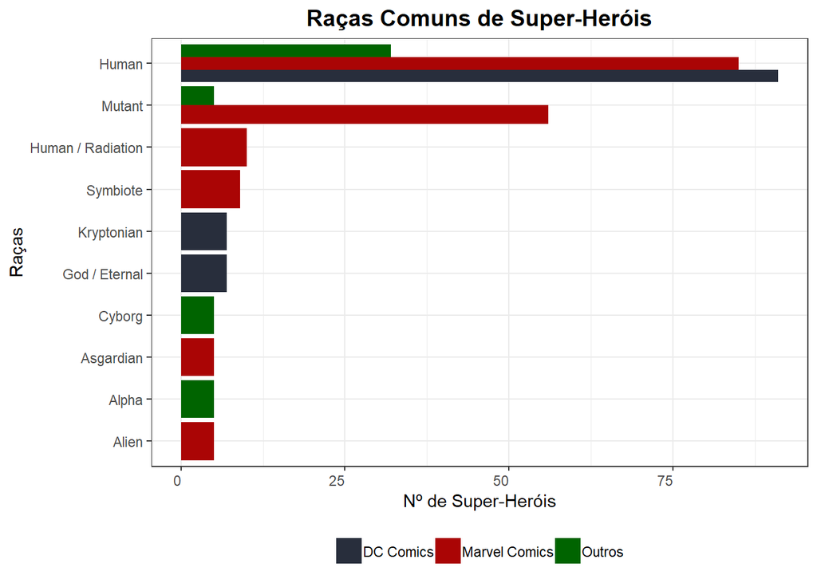

> A *Marvel* tem um pico em super-heróis mutantes, o que é, certamente, um reflexo dos *X-Men*. *DC* na quantidade de personagens humanos e apresenta “Deuses / Eternos” como uma marca registrada. Vemos que Asgardianos só existem no Universo *Marvel* enquanto que Kryptonianos são exclusividades da *DC*.

# Análise Univariada

#### Qual é a estrutura do conjunto de dados?

> Os dados são compostos por diversas fontes csv. As principais foram descritas e analisadas na trajetória acima. Basicamente, podemos dizer que há 734 heróis no *dataset* `heroes`, sendo catalogados atributos como nome, gênero, cor dos olhos, do cabelo e de pele, raça, altura (cm), peso (kg), lado (bem / mal / neutro) e editora. No *dataset* `powers` há 667 herois e 168 atributos em variáveis dummy: elas são verdadeiras se o personagem tem aquele poder ou falsa, caso contrário. O *dataset* `power_strengths` pontua com valores cada habilidade e há também outros arquivos com informações complementares (ano de criação, número de aparições) oportunas para alguns *joins*.

```
## Observations: 734
## Variables: 10
## $ name         <chr> "A-Bomb", "Abe Sapien", "Abin Sur", "Abomination"...
## $ Gender       <fct> Male, Male, Male, Male, Male, Male, Male, Male, F...
## $ `Eye color`  <chr> "yellow", "blue", "blue", "green", "blue", "blue"...
## $ Race         <chr> "Human", "Icthyo Sapien", "Ungaran", "Human / Rad...
## $ `Hair color` <chr> "No Hair", "No Hair", "No Hair", "No Hair", "Blac...
## $ Height       <dbl> 203, 191, 185, 203, NA, 193, NA, 185, 173, 178, 1...
## $ Publisher    <chr> "Marvel Comics", "Dark Horse Comics", "DC Comics"...
## $ `Skin color` <chr> NA, "blue", "red", NA, NA, NA, NA, NA, NA, NA, NA...
## $ Alignment    <fct> good, good, good, bad, bad, bad, good, good, good...
## $ Weight       <dbl> 441, 65, 90, 441, NA, 122, NA, 88, 61, 81, 104, 1...
```

```
##      name              Gender     Eye color             Race
##  Length:734         Female:200   Length:734         Length:734
##  Class :character   Male  :505   Class :character   Class :character
##  Mode  :character   NA's  : 29   Mode  :character   Mode  :character
##
##
##
##
##   Hair color            Height       Publisher          Skin color
##  Length:734         Min.   : 15.2   Length:734         Length:734
##  Class :character   1st Qu.:173.0   Class :character   Class :character
##  Mode  :character   Median :183.0   Mode  :character   Mode  :character
##                     Mean   :186.7
##                     3rd Qu.:191.0
##                     Max.   :975.0
##                     NA's   :217
##    Alignment       Weight
##  bad    :207   Min.   :  2.0
##  good   :496   1st Qu.: 61.0
##  neutral: 24   Median : 81.0
##  NA's   :  7   Mean   :112.3
##                3rd Qu.:108.0
##                Max.   :900.0
##                NA's   :239
```

#### Quais são os principais atributos de interesse deste conjunto de dados?

> Os atributos que despertam mais interesse são poder total, raça, gênero, número de aparições de um dado personagem

#### Quais outros atributos você acha que podem lhe auxiliar na investigação destes atributos de interesse?

> Atributos categóricos trazem muitas possibilidades, mas, sem dúvida, o *score* de uma habilidade específica e o fato de um personagem possuí-la ou não está diretamente relacionado com seu nível de poder.

#### Você criou novas variáveis a partir dos atributos existentes no conjunto de dados?

> Sim. Diversas variáveis são criadas ao longo na análise exploratória no sentido de possibilitar alguns plots - sua criação é explicada em curso. Podemos retomar a criação da variável densidade de aparições (número de aparições de um personagem / anos de existência) e da variável poder total, que foi o produto interno entre o vetor de habilidades específicas (0/1 ou False/True para uma lista de habilidades que um heroi possui) e o vetor de valor dessas habilidades, de modo a compor o ranking de personagens mais poderosos.

#### Dos atributos investigados, distribuições incomuns foram encontradas? Você aplicou operações nos dados para limpá-los, ajustá-los ou mudar a forma dos dados? Se sim, por quê?

> Conforme explicado nas primeiras manobras de análise exploratória, foram introduzidos valores *NA* para dados vistos por inspeção como discrepantes (valores negativos para pesos e alturas) ou assinalados por hífens sem valor. Dados numéricos também podem passar por transformações não-lineares como a aplicação do logaritmo natural para serem condensados no espaço de exibição

# Seção de Gráficos Bivariados

### *4.1. Peso e altura dos personagens por gênero*

> Haveria alguma distinção entre peso e altura dos personagens masculinos e femininos?

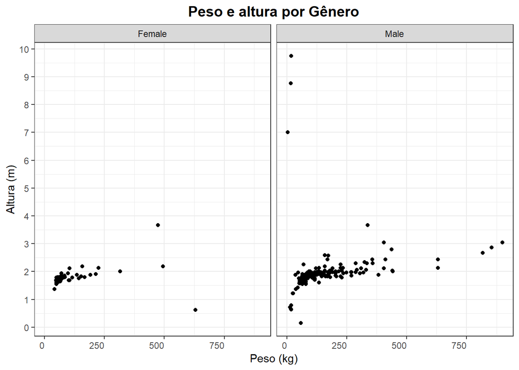

> Sim! as heroínas feminas aparentam ser muito mais leves e menores, ainda que existam alguns *outliers*. Há também personagens masculinos beirando os 10m, mas a normalidade concentra-se entre 1.5m a 2.0m, reflexo da alta composição humana no rol de personagens

### *4.2. Peso e altura dos personagens por editora*

> E haveria alguma variação nessas medidas por editora?

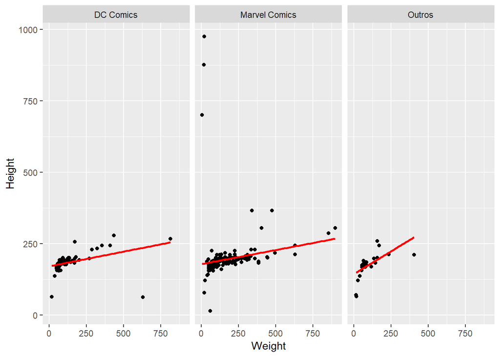

> Desta vez, a resposta é não. *Marvel* e *DC* são bem próximas nesse aspecto - as regressões lineares, ainda que sejam um modelo de baixo poder explanatório com R² baixo, demonstram a similaridade entre as editoras

### *4.3. Índice de Massa Corpórea (IMC) dos Personagens*

> Podemos avaliar altura e peso simultaneamente dos personagens pelo índice de massa corpórea (IMC), que é a razão entre massa e o quadrado da altura. Em tese, este índice é capaz de categorizar a normalidade da gordura corporal ou o sobrepeso.

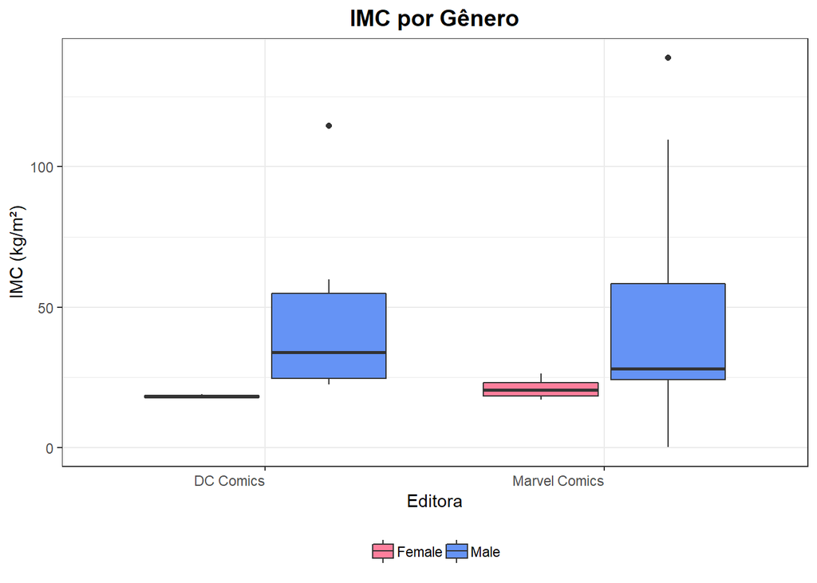

> Se lançarmos mão do limite superior saudável, que é 25, vemos que a maioria dos personagens encontram-se em risco de sobrepeso. Contudo, este valor é aplicável à raça humana, não podendo ser um parâmetro muito rígido de análise

> Se segmentarmos por raça…

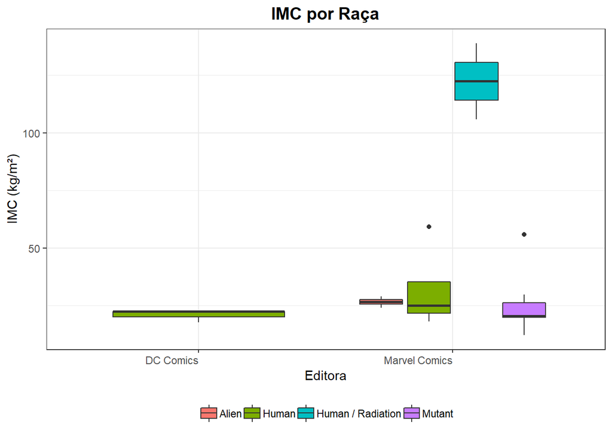

# Análise Bivariada

#### Discuta sobre alguns dos relacionamentos observados nesta parte da investigação. Como os atributos de interesse variaram no conjunto de dados?

> Como grande parte das variáveis são categóricas, gráficos de dispersão de valor foram minoria. Variações de peso, altura e IMC puderam ser vistos categoricamente nos *boxplots* e nos *scatterplots*.

#### Você observou algum relacionamento interessante entre os outros atributos (os que não são de interesse)?

> Há uma grande variabilidade entre peso, altura e IMC com variáveis categóricas como gênero - que inicialmente, não foram mapeadas como de interesse, a despeito da raça, por exemplo.

#### Qual foi o relacionamento mais forte encontrado?

> Foi visualizado um elevado IMC médio (que carrega consigo grande massas e alturas menores) fortemente correlacionado com a categoria de *humanos irradiados* - o efeito de densificação corpórea, supracitado. Valores menores de IMC foram observados em outras categorias de personagens

# Seção de Gráficos Multivariados

### *5.1.Poder Total por Lado e Editora*

#### Em um conflito final, - como a *Marvel* testou em seu roteiro de *Guerra Infinita* - se todos os personagens fossem reunidos, na ausência de uma estratégia, quem levaria a melhor?

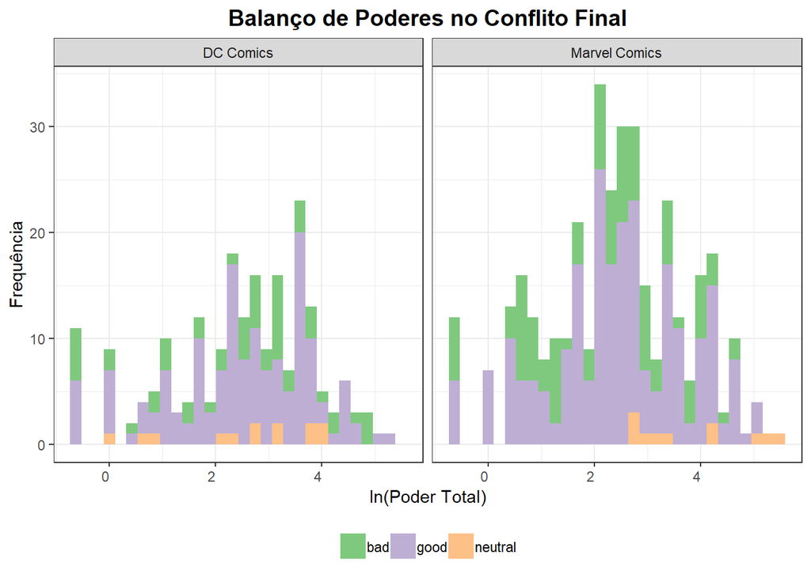

> Vemos pelo histograma empilhado que, para diversas faixas de poder, o bem é superior, possivelmente saindo vitorioso de um conflito generalizado. Ajustamos os valores de poder total pelo logaritmo natural apenas para um conforto visual - menores níveis de poder são mais frequentes na realidade É interessante destacar que, na *Marvel*, os personagens de maior poder apresentam alinhamento neutro, estando, literalmente, acima do bem e do mal.

### *5.2. Poder total por Gênero e Editora*

#### Se tivermos a mesma curiosidade, observando agora os gêneros…

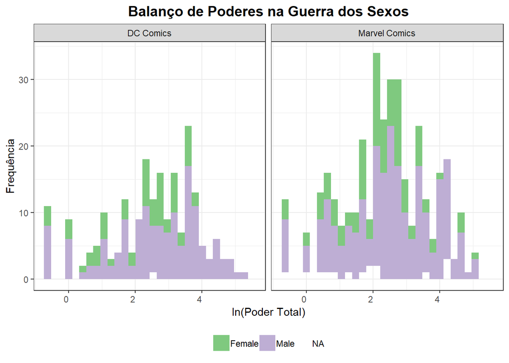

> … veremos que as proporções de personagens masculinos são preponderantemente mais poderosas nesse contexto. Além disso, é notável, especialmente na *Marvel*, personagens sem gênero declarado - *The One-Above-All*, o mais poderoso, é um deles

### *5.3. Mapa de Calor de Poderes por Raça*

#### Conhecendo-se uma raça, é possível prever quais poderes o personagem terá?

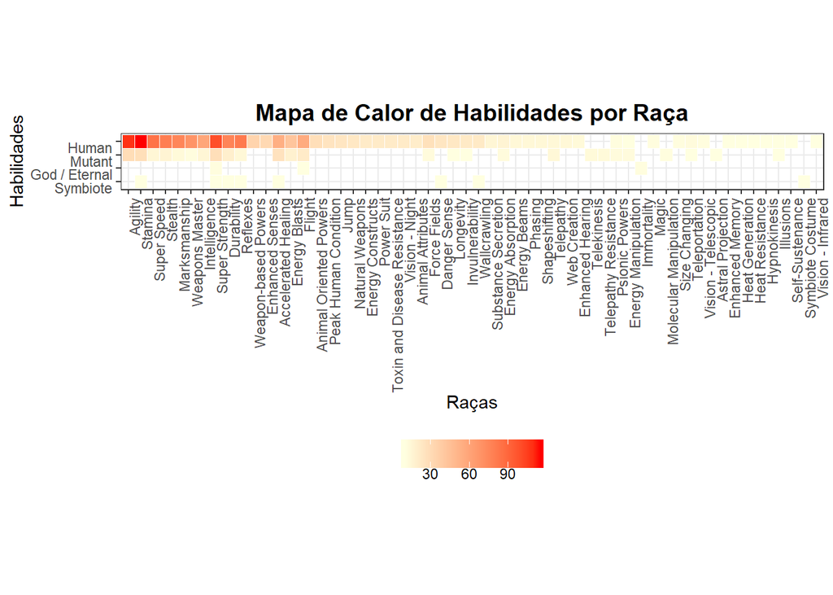

> Para nossa supresa, vimos que a raça mais habilidosa nas HQs é a humana mesmo, seguida dos mutantes e dos deuses/eternos.

# Análise Multivariada

#### Discuta sobre os relacionamentos observados nesta parte da investigação. Quais atributos que fortaleceram os demais na observação das variáveis de interesse?

> Reforçou-se, dentre as variáveis categóricas, que personagens do gênero masculino apresentam maior poder absoluto, o que também está correlacionado ao fato de existir mais personagens masculinos nos universos das editoras como um todo. O fato de o grupo de personagens benévolos sobrepor-se, em poder total, ao de malévolos corrobora com o aspecto de “bem moralizante” pregado pelas HQs, que ambém fomenta a esperança em nós de um bem definitivo no futuro.

#### Interações surpreendentes e/ou interessantes foram encontradas entre os atributos?

> Crê-se que a interação mais surpreendente foi a que descobriu que, nas relações de frequência entre raças e poderes, a raça mais poderosa das HQs é a humana. Foi interessante também ver que os personagens mais poderosos no universo *Marvel* em especial, não tem um lado definido num hipotético confronto final.

#### OPCIONAL: Modelos foram criados usando este conjunto de dados? Discuta sobre os pontos fortes e as limitações do seu modelo.

> Foram realizadas regressões lineares nos *scatterplots* de altura por peso, segmentados por editora, em explorações anteriores. Porém, por apresentarem baixo poder explicativo, tais regressões foram discutidas modestamente. A própria visualização do Mapa de Calor da seção 5.3. lança mão de um simples método de clusterização - ordenamento bidimensional - para ilustrar relações crescentes de importância do canto inferior direito ao canto superior esquerdo no gráfico.

# Gráficos Finais e Sumário

#### Primeiro Gráfico

[figure not shown]

#### Descrição do Primeiro Gráfico

> *Ranking* de poder dos herois. As habilidades específicas de cada um foram ponderadas pelos seus respectivos valores conforme disponível na [SHDb](https://www.superherodb.com/powers/). O pouco conhecido “The-One-Above-All” é o personagem mais poderoso da *Marvel*, rivalizando com “Spectre”, da *DC*. Neste top 20, vê-se que a *Marvel* é muito presente.

#### Segundo Gráfico

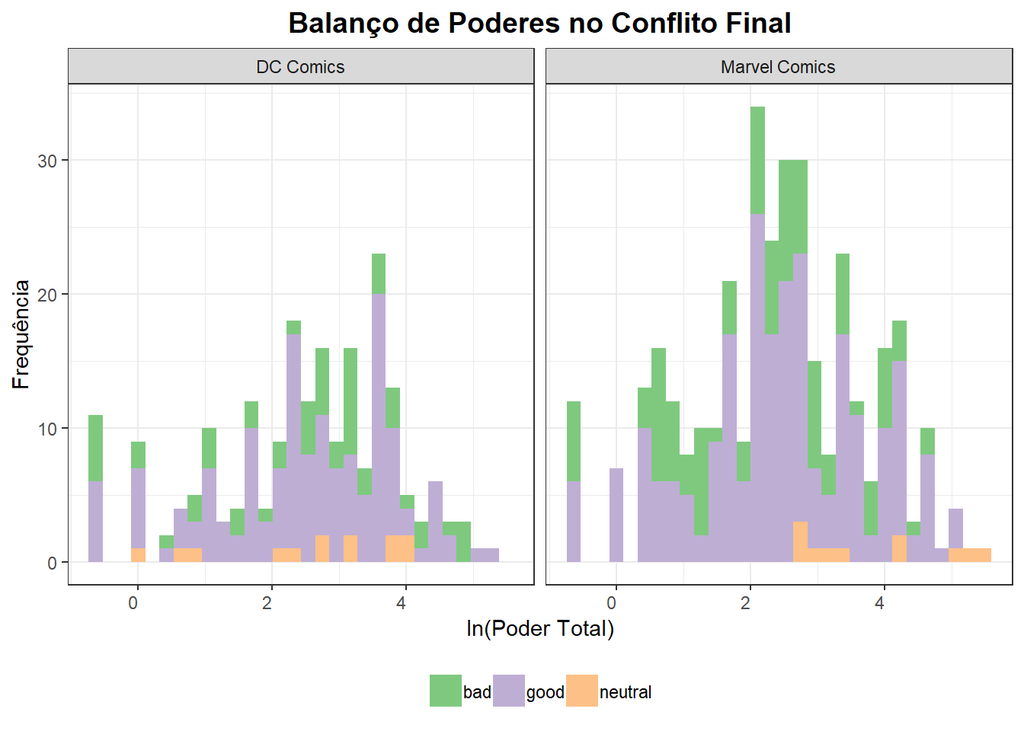

#### Descrição do Segundo Gráfico

> Balanço de poderes no conflito final. A batalha final movimenta muito a imaginação dos leitores de HQs, especialmente em um arco capaz de envolver todos os personagens. É interessante observar que os valores de poder total são apresentados transformados pelo logaritmo natural e temos a representação de uma distribuição semelhante à gaussiana. Da estatística, sabe-se que, se o logaritmo natural de um variável aleatória X qualquer leva a uma distribuiçao normal, o X original possivelmente segue uma distribuição exponencial, o que faz total sentido, até em termos de roteiro: há muitos personagens com pouco poder e poucos personagens com muito poder - o estabelecimento do conceito de raridade. O bem, mais poderoso, tem mais chances de vitória. Destaque novamente para a *Marvel*, com personagens poderosos estando acima do bem e do mal.

#### Terceiro Gráfico

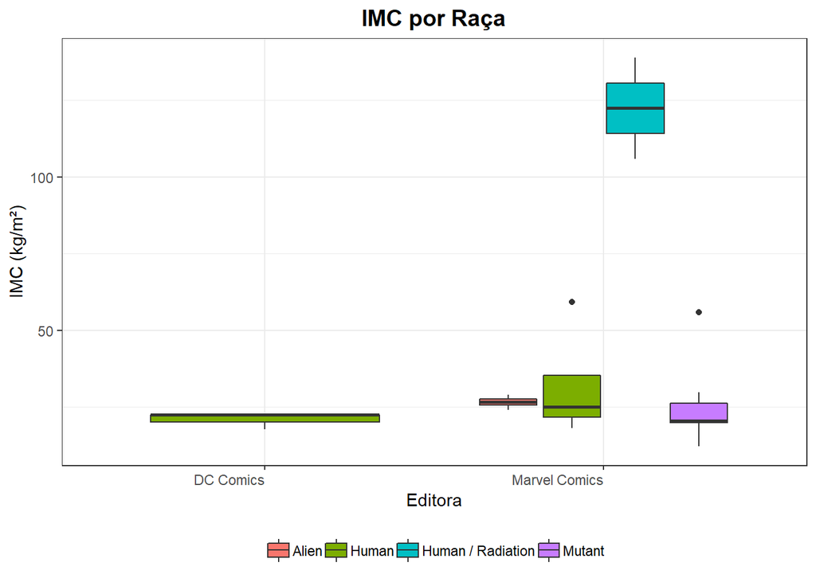

# Reflexão

> As principais dificuldades para análise do *dataset* de super-heróis podem ser sumarizadas na diversidade de fontes que o compõem e que precisaram ser, por diversas vezes, reunidas e agrupadas através de pacotes como `dplyr` e `sqldf`. Como o conjunto de dados apresenta muitas variáveis categóricas, que, frequentemente, precisam ser transformadas de fatores, não é trivial a busca por correlações entre atributos, como pode ser feito, por exemplo, explorando-se variáveis contínuas através de *Draftman’s plots* e exibindo-se matrizes de correlações de Pearson. Contudo, um *set* com muitas variáveis categóricas possibilita a exploração de castas - gêneros, raças, lado, editora etc. - e das semelhanças e diferenças entre elas.

> Indubitavelmente, este é um trabalho que reúne muitas lições aprendidas ao longo do curso e que dá confiança para análises exploratórias futuras. O *story-telling* se faz muito presente no modo como os dados embasam alguns fatos das HQs.

> Um dos momentos mais satisfatórios deste projeto foi a composição do poder total de cada personagem. Foi possível observar a dominância de personagens masculinos nos universos, revelar o herói mais poderoso - ainda que pouco conhecido -, confirmar a popularidade do Homem-Aranha, descobrir a raça humana como muito versátil nos universos *Marvel* e *DC*, testar a hipótese de que herois poderosos são raros - seguem uma distribuição exponencial que o logaritmo neperiano transforma em normal - e calcular, através dos histogramas, a preponderância do bem ante o mal. Uma perspectiva para trabalhos futuros seria o enriquecimento e consolidação da base de dados - há duas bem definidas: uma para os herois e outra para os poderes. Fazem-se necessárias mais variáveis numéricas para que possam ser conduzidos cálculos de índice de correlação palpáveis. Uma extrapolação dos dados dos personagens com informações cinematográficas também seria bem-vinda.